# Project: Analysis of No-Show Medical Appointments

- Introduction
- Data Wrangling
- Exploratory Data Analysis
- Conclusions

## Introduction

The data set to be investigated contains records of 110,527 medical appointments and it is associated to 14 variables (characteristics). The most important variable is the "No-show" column which indicates whether the patient show-up or no-show to the appointment. Below are list of Variables.

| VARIABLE | DESCRIPTION |
| --- | --- |
| PatientId | This is a unique identifier of each patient |
| AppointmentID | An ID unique to each scheduuled appointment |
| Gender | Show the gender(sex) of the patient |
| ScheduledDay | Date which the patients planned their medical visit |
| AppointmentDay | Date which patients are given for medical visit |
| Age | Age of the patient |
| Neighbourhood | Place the patient lives |
| Scholarship | Indicates if the patient is enrolled in welfare program of not |
| Hipertension | Indicates if a patients is Hypertensive or not |
| Diabetes | Indicates if a patients is Diabetic or not |
| Alcoholism | Indicates if a patient is an alcoholic or not |
| Handcap | Indicates if the patient is Handicaped |
| SMS_received | Indicates if the patient received an SMS for his/her appointment |
| No-show | Indicates if the patient show up for their appointment or not |

The following questions will be Answered in this report

- What Percentage of patients did not show up for their Appointment?
- Did Patients enrolled in the scholarship program show up for appointment more than others?
- Did younger patients show up for their appointment more than older patients?
- Which Gender has more Patients?
- Which Age has the higest number of patients?
- Which Location has the highest number of Patients Appointments?
- Which day of the week most Patients set up their appointment?
- Which day of the week is the most busiest?

```python
#import statements
import numpy as np
import pandas as pd
import matplotlib.pyplot as plt
import seaborn as sns
%matplotlib inline
```

## Data Wrangling

### General Properties

```python
# Load your data
df=pd.read_csv('KaggleV2-May-2016.csv')
df.info()
```

```
<class 'pandas.core.frame.DataFrame'>
RangeIndex: 110527 entries, 0 to 110526
Data columns (total 14 columns):
 #   Column          Non-Null Count   Dtype
---  ------          --------------   -----
 0   PatientId       110527 non-null  float64
 1   AppointmentID   110527 non-null  int64
 2   Gender          110527 non-null  object
 3   ScheduledDay    110527 non-null  object
 4   AppointmentDay  110527 non-null  object
 5   Age             110527 non-null  int64
 6   Neighbourhood   110527 non-null  object
 7   Scholarship     110527 non-null  int64
 8   Hipertension    110527 non-null  int64
 9   Diabetes        110527 non-null  int64
 10  Alcoholism      110527 non-null  int64
 11  Handcap         110527 non-null  int64
 12  SMS_received    110527 non-null  int64
 13  No-show         110527 non-null  object
dtypes: float64(1), int64(8), object(5)
memory usage: 11.8+ MB
```

```python
df.head()
```

|  | PatientId | AppointmentID | Gender | ScheduledDay | AppointmentDay | Age | Neighbourhood | Scholarship | Hipertension | Diabetes | Alcoholism | Handcap | SMS_received | No-show |
| --- | --- | --- | --- | --- | --- | --- | --- | --- | --- | --- | --- | --- | --- | --- |
| 0 | 2.987250e+13 | 5642903 | F | 2016-04-29T18:38:08Z | 2016-04-29T00:00:00Z | 62 | JARDIM DA PENHA | 0 | 1 | 0 | 0 | 0 | 0 | No |
| 1 | 5.589980e+14 | 5642503 | M | 2016-04-29T16:08:27Z | 2016-04-29T00:00:00Z | 56 | JARDIM DA PENHA | 0 | 0 | 0 | 0 | 0 | 0 | No |
| 2 | 4.262960e+12 | 5642549 | F | 2016-04-29T16:19:04Z | 2016-04-29T00:00:00Z | 62 | MATA DA PRAIA | 0 | 0 | 0 | 0 | 0 | 0 | No |
| 3 | 8.679510e+11 | 5642828 | F | 2016-04-29T17:29:31Z | 2016-04-29T00:00:00Z | 8 | PONTAL DE CAMBURI | 0 | 0 | 0 | 0 | 0 | 0 | No |
| 4 | 8.841190e+12 | 5642494 | F | 2016-04-29T16:07:23Z | 2016-04-29T00:00:00Z | 56 | JARDIM DA PENHA | 0 | 1 | 1 | 0 | 0 | 0 | No |

```python
df.describe()
```

|  | PatientId | AppointmentID | Age | Scholarship | Hipertension | Diabetes | Alcoholism | Handcap | SMS_received |
| --- | --- | --- | --- | --- | --- | --- | --- | --- | --- |
| count | 1.105270e+05 | 1.105270e+05 | 110527.000000 | 110527.000000 | 110527.000000 | 110527.000000 | 110527.000000 | 110527.000000 | 110527.000000 |
| mean | 1.474963e+14 | 5.675305e+06 | 37.088874 | 0.098266 | 0.197246 | 0.071865 | 0.030400 | 0.022248 | 0.321026 |
| std | 2.560949e+14 | 7.129575e+04 | 23.110205 | 0.297675 | 0.397921 | 0.258265 | 0.171686 | 0.161543 | 0.466873 |
| min | 3.920000e+04 | 5.030230e+06 | -1.000000 | 0.000000 | 0.000000 | 0.000000 | 0.000000 | 0.000000 | 0.000000 |
| 25% | 4.172615e+12 | 5.640286e+06 | 18.000000 | 0.000000 | 0.000000 | 0.000000 | 0.000000 | 0.000000 | 0.000000 |
| 50% | 3.173180e+13 | 5.680573e+06 | 37.000000 | 0.000000 | 0.000000 | 0.000000 | 0.000000 | 0.000000 | 0.000000 |
| 75% | 9.439170e+13 | 5.725524e+06 | 55.000000 | 0.000000 | 0.000000 | 0.000000 | 0.000000 | 0.000000 | 1.000000 |
| max | 9.999820e+14 | 5.790484e+06 | 115.000000 | 1.000000 | 1.000000 | 1.000000 | 1.000000 | 4.000000 | 1.000000 |

```python
sum(df.duplicated())
```

```
0
```

#### Observations made about the data

There are 110527 records, a total of 14 columns.

The data has no missing values.

There are three data types: integer, string and float.

AppointmentDay and ScheduledDay are representated as string object instead of date time

There are no duplicates

We see min Age as negative 1 (-1), which is impossible this could be typing error they data entry staff, so we decide to replace all -1 with 1.

### Data Cleaning

```python
#df['Age'] = df['Age'].replace(-1.0,1.0)
df['Age'].mask(df['Age'] <0 ,1, inplace=True)
```

We replace patient age that is less than zero(0) with 1

```python
df.rename(columns = {'No-show':'No_show'}, inplace = True)
```

The name of the last column (No-show) is causing error no windows machine when plotting charts like histogram, we had to rename it. So we rename the 'No-show' column to 'No_show'

```python
df['ScheduledDay'] = pd.to_datetime(df['ScheduledDay'])
df['AppointmentDay'] = pd.to_datetime(df['AppointmentDay'])
```

Here we Convert 'ScheduledDay' and 'AppointmentDay' columns to datetime

## Exploratory Data Analysis

#### Summary Statistics of Patients' Age

```python
df.Age.mean()
```

```
37.08887421173107
```

```python
df.Age.min()
```

```
0
```

```python
df.Age.max()
```

```
115
```

#### What Percentage of patients did not show up for their Appointment?

```python
Noshow1 = df['No_show'].value_counts('No')
print(Noshow1)
```

```
No     0.798067
Yes    0.201933
Name: No_show, dtype: float64
```

```python
Noshow = df['No_show'].value_counts()
print(Noshow)
```

```
No     88208
Yes    22319
Name: No_show, dtype: int64
```

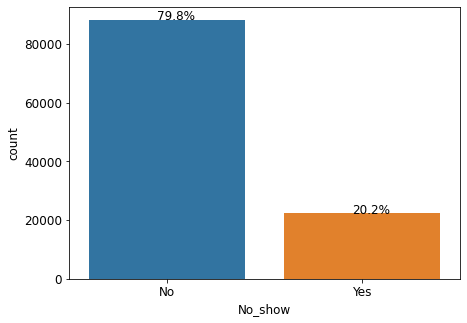

```python
import warnings
warnings.simplefilter(action="ignore", category=FutureWarning)

def without_hue(plot, feature):
    total = len(feature)
    for p in ax.patches:
        percentage = '{:.1f}%'.format(100 * p.get_height()/total)
        x = p.get_x() + p.get_width() / 2 - 0.05
        y = p.get_y() + p.get_height()
        ax.annotate(percentage, (x, y), size = 12)
    plt.show()

plt.figure(figsize = (7,5))
ax = sns.countplot('No_show',data = df)
plt.xticks(size = 12)
plt.xlabel('No_show', size = 12)
plt.yticks(size = 12)
plt.ylabel('count', size = 12)
without_hue(ax,df.No_show);
```

We can see only 20% of patients failed to show up for their appointments.

#### Did Patients enrolled in the scholarship program show up for appointment more than others?

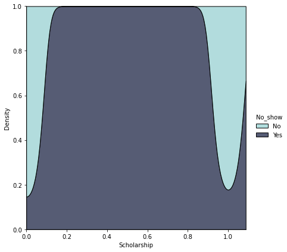

```python
sns.displot(data=df,x="Scholarship", hue="No_show", kind="kde", height=6,multiple="fill", clip=(0, None),
            palette="ch:rot=-.25,hue=1,light=.75");
```

#### Did younger patients show up for their appointment more than older patients?

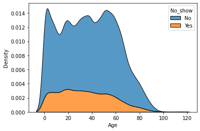

```python
sns.kdeplot(data=df, x="Age", hue="No_show", multiple="stack");
```

From the chart above it shows that most patients within the age of 0-100 show up for their appointment, However, looking at the No-show(Yes), we can see that those above 60 year are less likely to miss their appointment.

#### Which Gender has more Patients?

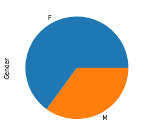

```python
df['Gender'].value_counts().plot(kind='pie');
```

This shows that there are more Female Patience than Male patients

#### Which Age has the higest nnumber of patients?

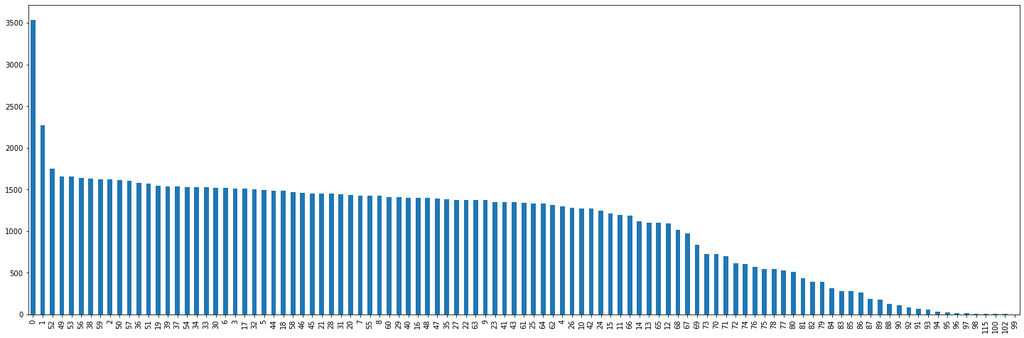

```python
df['Age'].value_counts().plot(kind='bar', figsize= (25,8));
```

This shows that children are age of zero(0) are more in number than any age group

#### Which Location has the highest number of Patients Appointments?

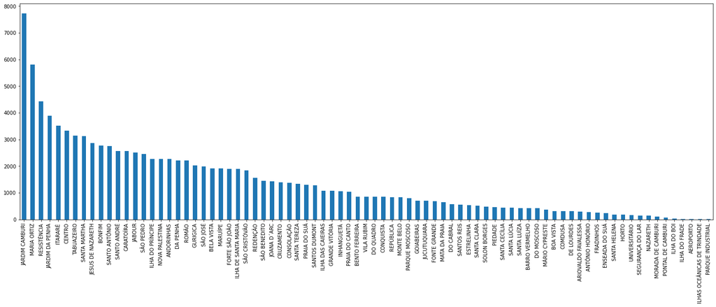

```python
df['Neighbourhood'].value_counts().plot(kind='bar',  figsize= (25,8));
```

Jardim Camburi has the highest number of patient appointments

#### Which day of the week most Patients set up their appointment?

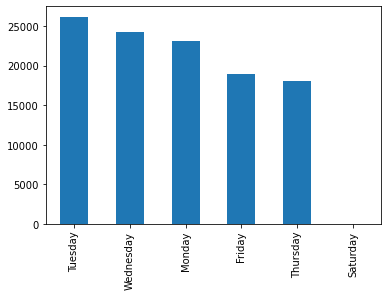

```python
weekdays = df['ScheduledDay'].dt.day_name()
weekdays.value_counts().plot(kind='bar');
```

Most patients scheduled their Appointments on Tuesdays.

#### Which day of the week is the most busiest?

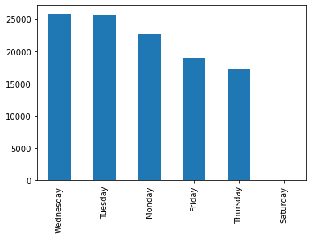

```python
weekdaysa = df['AppointmentDay'].dt.day_name()
weekdaysa.value_counts().plot(kind='bar');
```

Most patients got their appointment fixed on Wednesdays.

## Conclusions

Generally, most of the patient are Females, and we can also see that most patients (80%) attended their Medical appointment.

Finally, patieints above age 60 seems to show up for their appointment more.

## References

- https://stackoverflow.com/questions/35692781/python-plotting-percentage-in-seaborn-bar-plot
- https://seaborn.pydata.org/